# Can Urban-Music Streaming Improve Forecasts of Vox Support?

A monthly prediction test using CIS estimates and Spotify’s Spain Top 200

Ali Rıza Genç (s5265126) · Applied AI for Political Scientists, Final Project (Track A) · Leiden University

30 October 2026

**Main finding**Adding the artists’ chart-listed Spotify streams lowered the error of a polling-only ridge model by 0.23 percentage points in 2024 development validation but raised it by 1.29 points on the frozen 2025 test. Simply repeating the last CIS estimate beat every learned model in both periods.

# 1 Question and data

Do chart-listed Spotify streams for Morad, Beny Jr and Cyril Kamer improve forecasts of Vox’s national CIS-published vote-share estimates beyond the information contained in earlier CIS releases?

Each forecast is issued on the 10th of a month and targets the CIS estimates first published between the 10th of the next month and the 10th of the month after. This is a **prediction** question; nothing here identifies a cause.

**Why a political scientist should care.** Digital traces are often proposed as early signals of political change, yet they rarely survive out-of-sample tests (Gayo-Avello 2013); such tests show whether a measure carries information that existing indicators lack (Cranmer and Desmarais 2017). Vox is a nationalist radical-right party. In the 2018 Andalusian election, its support was better explained by concerns about devolution than by attitudes to immigration (Turnbull-Dugarte 2019). Spain’s most visible drill scene, M.D.L.R., comes from working-class, migrant-descended neighbourhoods; Ahmed González (2024) discusses Morad and Beny Jr, sons of Moroccan immigrants from L’Hospitalet, as part of this scene. Cyril Kamer, a Spain-based rapper in my protocol, is not discussed there, so I claim no affiliation. If this scene’s national visibility moved with the climate Vox mobilises, its chart presence might carry a forecasting signal. The literature gives little reason to expect one.

**Outcome.** The CIS *estimación de voto* for Vox, in percent of the valid vote: a published, model-based polling series, neither the *voto directo* column (percent of the census) nor an election result. Each value was extracted from the original PDF by code and checked by eye (`data/interim/cis_vox_manual_check.csv`). Each barometer is dated by its official first-release (*avance*) date. CIS regenerated six 2024 PDFs on one day, so for these I also checked the value against same-day press reports of the first release. Windows without a release (August has no barometer) are dropped, not filled.

**Predictors.** Three polling inputs known at the origin: the latest estimate, its change from the previous release, and days since that release (a release *on* the 10th counts from the 11th). For each artist, `log1p` of mean weekly streams of tracks crediting them (collaborations included) in Spotify’s weekly Spain Top 200, over weeks ending in the previous month. A week without a chart entry is zero *chart-listed* streams, not zero listening; no chart file was missing. Weeks count as available eight days after they end, a declared convention.

Table 1. Development sample

| Quantity | Count |
| --- | --- |
| CIS barometers (Nov 2022 – Dec 2024; the two 2022 releases enter only as history) | 24 |
| Monthly forecast origins, Jan 2023 – Oct 2024 | 22 |
| Usable development cases (inputs and a target; July 2023 and July 2024 have no release in the window) | 20 |
| Training cases available before the first 2024 validation block | 9 |
| Weekly Spain Top 200 files audited (Dec 2022 – Dec 2024) | 109 |

Source: original CIS barometer PDFs and Spotify weekly charts; counts computed from the frozen model frame.

Table 1 shows how small the problem is: 20 usable months, of which only 9 precede the first validation block.

**Design history.** My design of 14 October, the course’s deadline, forecast Fratelli d’Italia’s polling from Italian rap streaming. I then accidentally gave an AI tool access to Italian files meant for training and testing, by my account including at least one late-2025 chart (not independently documented). No Italian model had been fitted, so this was possible design contamination, not demonstrated model leakage. As a precaution I restarted with Spain, after the deadline and without instructor approval; the Spain protocol predates any Spain analysis.

**Decisions that could have gone otherwise**, each dated in `AMENDMENTS.md` (times from files, not version control):

- *CIS only*: auditing other pollsters’ release dates and permissions was not feasible in time.
- *Monthly, not weekly*: the protocol’s weekly design needed 30 training weeks; CIS gives 10, so its pre-specified monthly fallback applied, decided on poll counts before any music feature existed.
- *Weekly charts aggregated to months*, as I hold no daily charts.
- *Three artists, not five*: Delarue and Moha The B never entered the Top 200 in 109 weeks (Morad 109, Beny Jr 101, Cyril Kamer 74), so their measure would be constant. I dropped them after a names-and-week-counts audit, before computing any stream value, departing from my protocol.

# 2 What I did, and why that

I compare three forecasts on identical cases.

Table 2. Forecasting models

| Model | Inputs | Role |
| --- | --- | --- |
| M0 Persistence | Latest published CIS estimate | Benchmark every model must beat |
| M1 Polling-only ridge | Latest estimate, last change, days since release | What polling history alone predicts |
| M2 Polling + Spotify ridge | M1 inputs + three artists’ chart-listed streams | Adds the music signal |

The quantity of interest is the difference in mean absolute error, M2 minus M1. A negative value would mean the streams add information. Beating M1 is not enough, however, if both lose to persistence, a hard benchmark for slow-moving series (Hyndman and Athanasopoulos 2021).

**Why ridge.** With so few training cases and correlated inputs, unpenalised regression would produce unstable coefficients. Ridge shrinks every coefficient while keeping all pre-chosen inputs, so M1 and M2 differ only by the music variables (Hoerl and Kennard 1970). The lasso, the obvious alternative, would with this little data delete inputs erratically and so change the comparison itself. Elastic net (α = 0.5), which mixes both penalties (Zou and Hastie 2005), serves as the one robustness check. All models use `glmnet` (Friedman, Hastie and Tibshirani 2010).

**Training and validation.** The data are a time series, so nothing is split at random. In 2024 the models are validated forward in three quarterly blocks (Table 3). A training case enters only if its target window had closed and its releases were public before the block’s cutoff. Scaling is learned on each block’s training cases only. The penalty λ is chosen from a fixed grid of 80 values by pooled mean absolute error over the 2024 validation forecasts. The 2024 errors therefore also served for tuning and **are not an independent estimate of performance**.

Table 3. Forward validation in 2024

| Block | Training cutoff | Training cases | Forecasts | Forecast origins |
| --- | --- | --- | --- | --- |
| 2024 Q1 | 01 Jan 2024 | 9 | 3 | Jan, Feb, Mar |
| 2024 Q2 | 01 Apr 2024 | 12 | 3 | Apr, May, Jun |
| 2024 Q3 | 01 Jul 2024 | 15 | 2 | Aug, Sep |

July 2024 has no forecast because its target window (10 Aug – 10 Sep) contains no CIS release.

Training thus grows only from 9 to 15 cases (Table 3). After tuning, each model was refitted on all 20 development cases, and the code, model frame and fitted models were hashed (17:38, 29 October 2026). I then opened 2025 once, as an **exploratory out-of-time test** (scoring lock 18:10). Today’s files match that manifest, though the order of events rests on file timestamps, not an authenticated log.

**Reproducibility checks run at every knit (all must pass for this page to exist)**

```r
# 1. Raw CIS PDFs are byte-identical to the inventory, and every value was checked by eye.
pdf_files <- p("data/raw/cis_2023_2024", cis$year, cis$file)
stopifnot(all(vapply(pdf_files, sha, "") == cis$sha256), all(cis$verified_by_eye))

# 2. Raw PDFs -> targets: re-extract the Vox estimate (3rd number of the VOX row) now.
extract_vox <- function(f) {
  pg <- pdftools::pdf_text(f)
  ok <- grepl("voto v.{1,2}lido", pg, ignore.case = TRUE) & grepl("voto directo", pg, ignore.case = TRUE)
  ln <- strsplit(pg[max(which(ok))], "\n", fixed = TRUE)[[1]]
  row <- ln[grepl("^\\s*VOX\\b", ln)]
  tok <- regmatches(row, gregexpr("[\\x{00B1}+-]?\\s?[0-9]{1,3}(?:,[0-9]{1,2})?(?![0-9])", row, perl = TRUE))[[1]]
  as.numeric(sub(",", ".", tok[3], fixed = TRUE))
}
stopifnot(isTRUE(all.equal(vapply(pdf_files, extract_vox, 0), cis$vox_estimate_valid, check.attributes = FALSE)))

# Manifest lines are "<relative path> <sha256>"; the hash is the last field, so paths may contain spaces.
read_manifest <- function(f) {
  x <- grep("\\s[0-9a-f]{64}$", readLines(f), value = TRUE)
  cbind(sub("\\s+[0-9a-f]{64}$", "", x), sub("^.*\\s", "", x))
}

# 3. The frozen model, code and model frame are unchanged since the freeze.
man <- read_manifest(p("reports/results/fit_freeze_manifest.txt"))
stopifnot(nrow(man) == 4)
stopifnot(all(vapply(p(man[, 1]), sha, "") == man[, 2]))

# 4. Rebuild: re-run the fitting script on the frozen model frame in a temporary folder
#    and compare with the frozen development metrics.
tmp <- tempfile("rebuild"); dir.create(file.path(tmp, "R"), recursive = TRUE)
dir.create(file.path(tmp, "data/processed"), recursive = TRUE)
invisible(file.copy(p("R/08_fit_models.R"), file.path(tmp, "R")))
invisible(file.copy(p("data/processed/model_frame_monthly.csv"), file.path(tmp, "data/processed")))
local({                       # run inside the temporary folder only; working directory is restored
  owd <- setwd(tmp); on.exit(setwd(owd))
  invisible(capture.output(source("R/08_fit_models.R", local = new.env())))
})
rebuilt <- read.csv(file.path(tmp, "reports/results/model_metrics.csv"))
stopifnot(max(abs(as.matrix(rebuilt[, 3:6]) - as.matrix(dev[, 3:6]))) < 1e-8)

# 5. The 2025 test was scored once, with exactly these inputs and code.
lock <- read_manifest(p("reports/results/test2025_lock.txt"))
stopifnot(nrow(lock) == 10)
stopifnot(all(vapply(p(lock[, 1]), sha, "") == lock[, 2]))

# 6. Reported metrics equal those recomputed from the frozen prediction files.
recompute <- function(p) do.call(rbind, lapply(split(p, list(p$design, p$model), drop = TRUE), function(d)
  data.frame(design = d$design[1], model = d$model[1], MAE = mean(abs(d$prediction - d$observed)))))
for (pair in list(list(fp, dev), list(p25, t25))) {
  r <- recompute(pair[[1]]); m <- merge(r, pair[[2]], by = c("design", "model"))
  stopifnot(max(abs(m$MAE.x - m$MAE.y)) < 1e-10)
}
cat("All six checks passed.")
```

```
## All six checks passed.
```

Checks 1–2 run from the raw CIS PDFs; the music features enter through the hashed model frame. A separate rebuild from the raw chart files to this frame, run on the author’s computer, is documented in `reports/audit/repro/`.

# 3 What I found, and how well I measured it

**The streaming indicators did not deliver robust incremental forecasting value, and persistence beat every learned model in both periods.**

Table 4. Forecast error by model and period

| Model | 2024 development validation (n = 8) MAE | 2024 development validation (n = 8) RMSE | 2024 development validation (n = 8) Bias | 2025 exploratory test (n = 9) MAE | 2025 exploratory test (n = 9) RMSE | 2025 exploratory test (n = 9) Bias |
| --- | --- | --- | --- | --- | --- | --- |
| Persistence | 1.25 | 1.45 | −1.00 | 1.91 | 2.28 | −0.69 |
| Polling-only ridge | 1.60 | 1.90 | −0.63 | 4.33 | 4.94 | −4.33 |
| Polling + Spotify ridge | 1.38 | 1.66 | −0.88 | 5.63 | 7.02 | 1.73 |

All values in percentage points (pp) of the CIS vote-share estimate. MAE: mean absolute error; RMSE: root mean squared error (penalises large misses); Bias: mean of prediction minus observed. 2024 errors were also used to choose λ; 2025 forecasts come from models frozen before 2025 was opened. Forecasts issued in July 2024 and July 2025 are absent because no CIS release fell in their target window.

In development, the music variables lowered the ridge model’s error by 0.23 points (M2 1.38 pp against M1 1.60 pp). Persistence was still better, at 1.25 pp. On the 9 forecasts for 2025 the sign reversed: M2 erred by 5.63 pp, 1.29 points more than M1 (4.33 pp), while persistence erred by 1.91 pp. With 8 and 9 forecasts these differences are descriptive; I report no significance tests.

The bias columns show *how* the models failed in 2025. The polling-only model under-forecast every month (bias −4.33 pp, equal in size to its MAE): its development-selected penalty (λ = 3.30) had shrunk it towards the 2023–24 average. The music model was almost unpenalised (λ = 0.0039). Its positive bias (+1.73 pp) comes from its last three forecasts (August to October), which jumped to between 26.56 and 29.75 per cent and account for 63% of its absolute error; before that it also under-forecast (mean bias −2.74 pp).

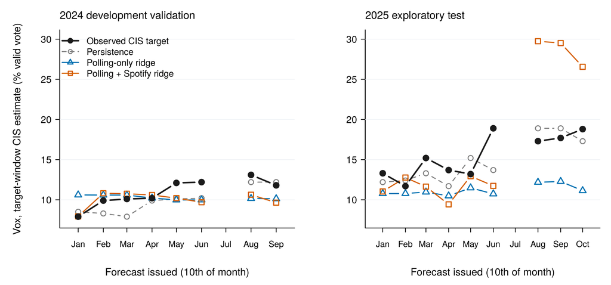

Figure 1. Observed target and forecasts, in % of the valid vote. Each point is a forecast issued on the 10th of the month shown; the observed value is the mean CIS estimate first released between the 10th of the next month and the 10th of the month after. Left: 2024 development validation, whose errors were also used to choose λ. Right: exploratory 2025 test of the frozen models. The periods are not joined.

Figure 1 makes the reversal visible. In 2024 the two ridge models track each other closely. In 2025 the polling-only model stays flat below the rising observed series, and the music model breaks away upwards in its last three forecasts.

Table 5. The check: difference in MAE when the music variables are added

| Estimator for M1 and M2 | M2 − M1, 2024 | M2 − M1, 2025 |
| --- | --- | --- |
| Ridge (main analysis) | −0.23 pp | +1.29 pp |
| Elastic net, α = 0.5 (the check) | −0.22 pp | +2.06 pp |

Negative values favour adding the Spotify variables. Same cases, inputs, folds, penalty grid and scoring rule in both rows.

**The check.** A real signal should not depend on the penalty, so I replaced both ridge models with elastic net and changed nothing else. The conclusion did not move (Table 5): the music variables helped slightly in development (−0.22 pp) and hurt in 2025 (+2.06 pp). The small development gain is therefore not specific to ridge, and it did not survive the change of period; this does not show that the streams carry no signal.

# 4 What I do not trust

**What this establishes.** With this sample and procedure, the artists’ chart-listed streams did not improve forecasts robustly, did not beat persistence, and the development gain reversed out of time. **What it does not establish.** It does not show that cultural visibility is unrelated to radical-right politics, that a different measure or model would fail, or anything causal in either direction.

**Limitation 1: too few independent forecasts, reused for tuning.** M2 has six inputs and at most 15 training months. The same 8 forecasts chose λ and produced the development scores. Tuning chose almost no shrinkage for M2 and heavy shrinkage for M1, a pattern consistent with fitting noise and with the extreme late-2025 music-model forecasts. The remedy is not more features but more independent targets (for example several pollsters under the same first-release rules, making the weekly design feasible) and nested tuning.

**Limitation 2: the music measure sees chart hits, not audiences.** A Top 200 count records an artist only in weeks with a hit; two planned artists never charted, and Cyril Kamer was absent in 3 of 22 months. The variable may track release cycles and platform dynamics more than political context. A valid test needs artist-level stream totals for all five artists, defined before modelling.

**Limitation 3: design history and exposure.** The design is narrower than planned and post-dates the course deadline (Section 1). I decided to open 2025 after seeing the development results, and AI-assisted searches had returned 2025–26 Spanish polling headlines (records ES-E01–E03 and E06 in `reports/audit/`; no value used), so 2025 is exploratory, not a pristine holdout. The monthly unit was not confirmed with the instructor.

# References

Ahmed González, S. (2024). Autenticidad, colectividad e identidad: el drill M.D.L.R. en España. *TRANS – Revista Transcultural de Música*, 28. https://www.sibetrans.com/trans/articulo/677/autenticidad-colectividad-e-identidad-el-drill-m-d-l-r-en-espana

Cranmer, S. J., & Desmarais, B. A. (2017). What can we learn from predictive modeling? *Political Analysis*, 25(2), 145–166.

Friedman, J., Hastie, T., & Tibshirani, R. (2010). Regularization paths for generalized linear models via coordinate descent. *Journal of Statistical Software*, 33(1), 1–22.

Gayo-Avello, D. (2013). A meta-analysis of state-of-the-art electoral prediction from Twitter data. *Social Science Computer Review*, 31(6), 649–679.

Hoerl, A. E., & Kennard, R. W. (1970). Ridge regression: Biased estimation for nonorthogonal problems. *Technometrics*, 12(1), 55–67.

Hyndman, R. J., & Athanasopoulos, G. (2021). *Forecasting: Principles and practice* (3rd ed.). OTexts. https://otexts.com/fpp3/

Turnbull-Dugarte, S. J. (2019). Explaining the end of Spanish exceptionalism and electoral support for Vox. *Research & Politics*, 6(2), 1–8. https://doi.org/10.1177/2053168019851680

Zou, H., & Hastie, T. (2005). Regularization and variable selection via the elastic net. *Journal of the Royal Statistical Society: Series B*, 67(2), 301–320.

**Data and code:** https://github.com/alirzgenc-arch/Genc_AliRiza_FinalProject (downloaded automatically when this file is knitted outside the project folder). Centro de Investigaciones Sociológicas, *Barómetros*, “Estimación de voto” PDFs, November 2022 – November 2025 (cis.es), with first-release dates and source links in `data/metadata/`. Spotify Charts, Weekly Top Songs Spain, December 2022 – September 2025 (charts.spotify.com). The instructor advised that no permission was needed for this course project; the raw files are included in the project repository (`README_REPRODUCE.md`).

# Appendix: AI use

[output not shown]

One row per task episode. Prompts and chat logs are not included, as the guide requires.

**What the tools were good and bad at.** AI was most useful for the safeguards I would not have built alone: hash checks, release-date rules and a lock that prevents re-scoring the test. It was also quick at diagnosing errors. It was unreliable wherever the answer depended on the documents themselves. It assumed the wrong column of the CIS table, guessed the wrong reason four PDFs failed, matched unrelated musicians in its first artist search, and once attributed a claim to a source that does not make it. I caught each of these only by opening the original PDF, chart file or article. It also tended to propose more procedure than a short project needs, so I had to decide what mattered.